# Untitled

Zhiming Guo

May 23, 2016

Load required libraries

```r
# Data wrangling
library(lubridate)
library(dplyr)

# For plotting
library(ggplot2)

# For regression tree
# library(MASS)
library(tree)

# For bagging and random forest models
library(randomForest)

### For the boosting model
library(gbm)


### For tuning models
library(caret)


### Fo xgboost model
library(xgboost)
```

Load and clean up data:

```r
load("data-raw/ListOfAllHeatwaves.Rdata")
fix_colnames <- which(colnames(all.hws) == "mean.temp")
colnames(all.hws)[fix_colnames[2]] <- "mean.temp.1"

hw <- all.hws %>%
  mutate(start.year = year(start.date))
colnames(hw) <- gsub(" ", ".", colnames(hw))
```

Create dataframes for fitting models for y2 and y2:

```r
hw <- hw %>%
  select(-hw.number, -start.date, -end.date, -id, -Std..Error,
         -city, -Posterior.Estimate, -Posterior.SE, -post.se)


to_fit_y2 <- hw %>%
  select(-Estimate)

# Create a random subset of heat waves to use to train models
set.seed(1001) ##generate fixed random numbers
hw_indices <- 1:nrow(hw)

train <- sort(sample(hw_indices, length(hw_indices) / 2))
head(train)
```

```
## [1]  2  3  5  6  9 11
```

```r
test <- hw_indices[-train]
head(test)
```

```
## [1]  1  4  7  8 10 12
```

Fit a regression tree for $Y_1$:

```r
tree.hw <- tree(post.estimate ~ ., data = to_fit_y2, subset = train)
summary(tree.hw)
```

```
##
## Regression tree:
## tree(formula = post.estimate ~ ., data = to_fit_y2, subset = train)
## Variables actually used in tree construction:
## [1] "mean.temp.quantile" "pop.density"        "mean.summer.temp"
## [4] "max.temp.quantile"  "pop100"
## Number of terminal nodes:  7
## Residual mean deviance:  0.0007427 = 1.101 / 1483
## Distribution of residuals:
##      Min.   1st Qu.    Median      Mean   3rd Qu.      Max.
## -0.096600 -0.017560 -0.001247  0.000000  0.016880  0.125800
```

The variables included in this model are: mean.temp.quantile, pop.density, mean.summer.temp, max.temp.quantile, pop100. Here is a plot of the final tree for this model:

```r
plot(tree.hw)
text(tree.hw, pretty = 0)
```

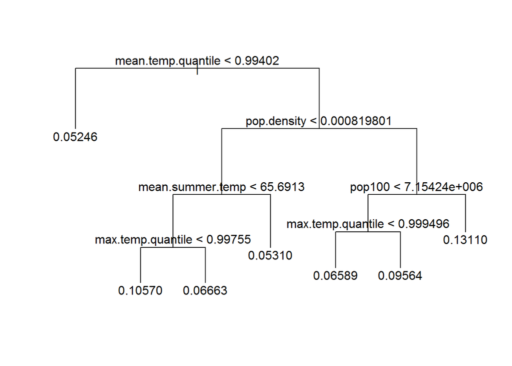

Here are the results of using cross-validation to decide whether (and how much) to prune the tree:

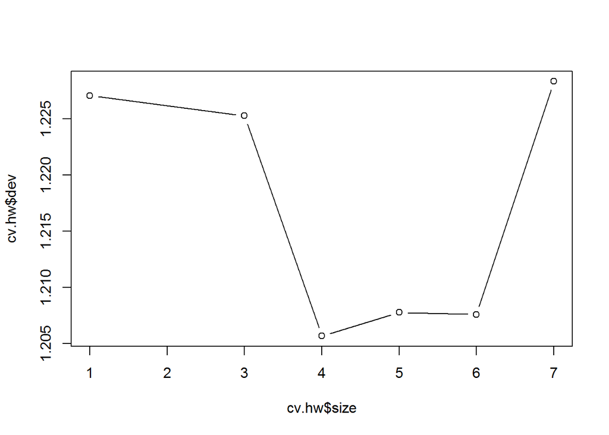

```r
cv.hw <- cv.tree(tree.hw)
plot(cv.hw$size, cv.hw$dev, type='b')
```

[figure not shown]

Here are the results of using cross-validation to decide whether (and how much) to prune the tree:

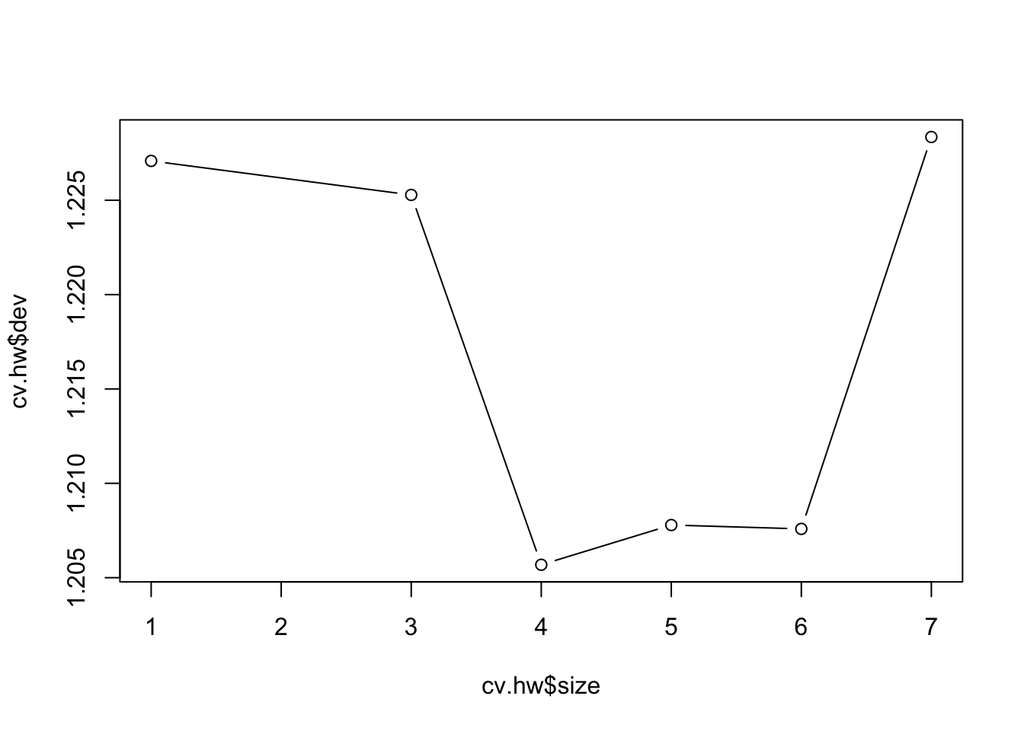

```r
cv.hw <- cv.tree(tree.hw)
plot(cv.hw$size, cv.hw$dev, type='b')
```

```r
yhat <- predict(tree.hw, newdata = to_fit_y2[test, ])

to_plot <- data.frame(post.estimated_y2 = yhat,
                      true_y2 = to_fit_y2[test, "post.estimate"])
ggplot(to_plot, aes(x = post.estimated_y2, y = true_y2)) +
  geom_point(alpha = 0.2) +
  xlim(range(to_plot)) + ylim(range(to_plot)) +
  theme_minimal() +
  geom_abline(intercept = 0, slope = 1) +
  xlab("post.estimated Y_1") + ylab("True Y_1")
```

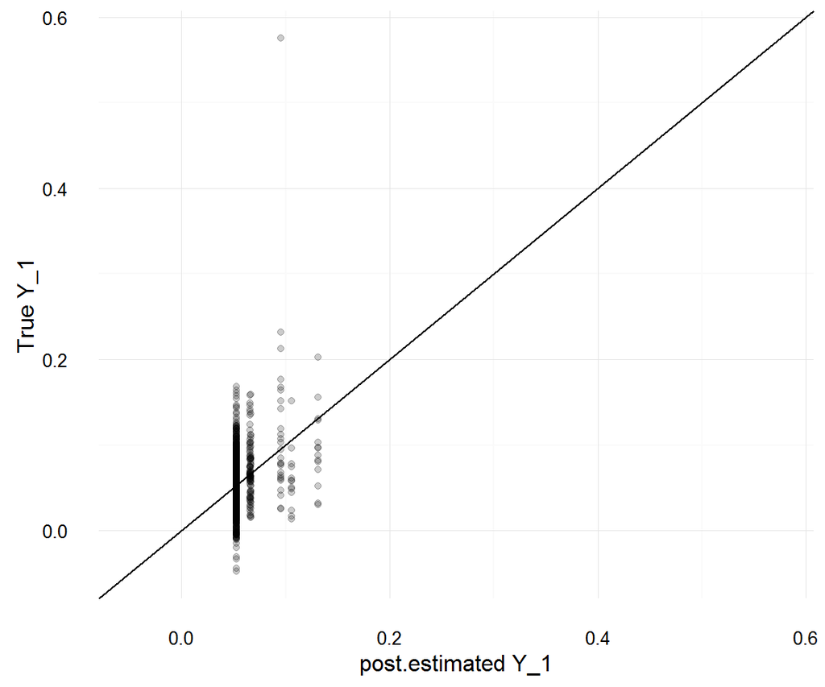

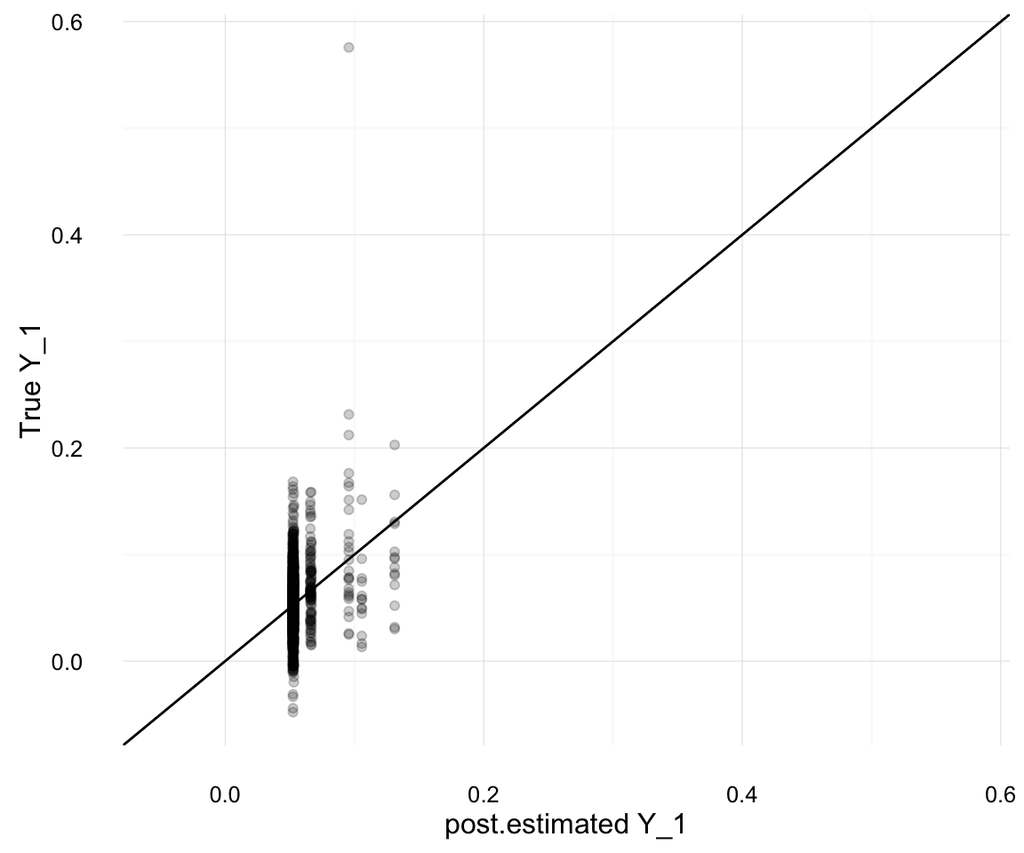

Fit a bagging model:

```r
set.seed(1)
bag.hw <- randomForest(post.estimate ~ .,
                       data = to_fit_y2, subset = train,
                       mtry = ncol(to_fit_y2) - 1, importance = TRUE)

yhat.bag <- predict(bag.hw, newdata = to_fit_y2[test, ])

to_plot <- data.frame(post.estimated_y2 = yhat.bag,
                      true_y2 = to_fit_y2[test, "post.estimate"])
ggplot(to_plot, aes(x = post.estimated_y2, y = true_y2)) +
  geom_point(alpha = 0.2) +
  xlim(range(to_plot)) + ylim(range(to_plot)) +
  theme_minimal() +
  geom_abline(intercept = 0, slope = 1) +
  xlab("post.estimated Y_1") + ylab("True Y_1")
```

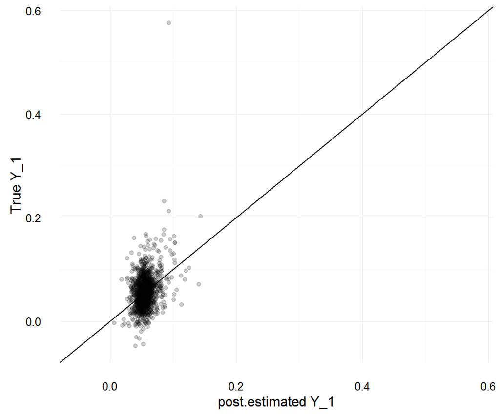

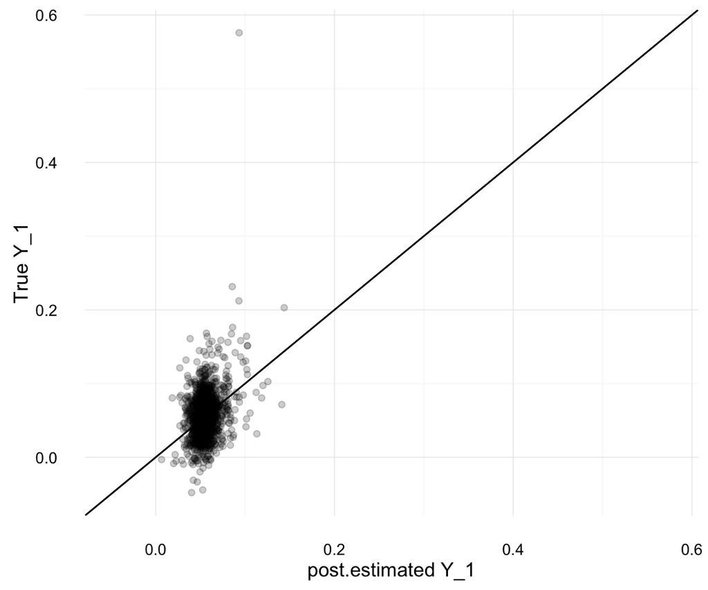

Here is more on the variable importance for this model:

```r
importance(bag.hw)
```

```
##                      %IncMSE IncNodePurity
## mean.temp          14.029886   0.058122296
## max.temp           11.620166   0.049093873
## min.temp           10.414608   0.036196754
## length              9.987650   0.039335285
## start.doy           9.499296   0.118367102
## start.month         5.717454   0.013113447
## days.above.80       8.673424   0.030334891
## days.above.85       5.824081   0.011961210
## days.above.90       4.224166   0.014209886
## days.above.95       1.272299   0.005584852
## days.above.99th     8.039198   0.022496658
## days.above.99.5th   4.780957   0.012043953
## first.in.season     3.039769   0.014023229
## mean.temp.quantile 22.309043   0.106775412
## max.temp.quantile  17.407236   0.091067595
## min.temp.quantile  11.688501   0.089249518
## pop100             12.234510   0.080961937
## Ppoverty            7.106601   0.032634877
## Ppoverty75p         8.040008   0.032896144
## Purban             10.823843   0.032030230
## P75p                5.750097   0.043796765
## pop.density        11.952227   0.045069450
## mean.temp.1        11.593717   0.045116205
## mean.summer.temp   11.972652   0.036003989
## start.year          8.151988   0.092896439
```

```r
varImpPlot(bag.hw)
```

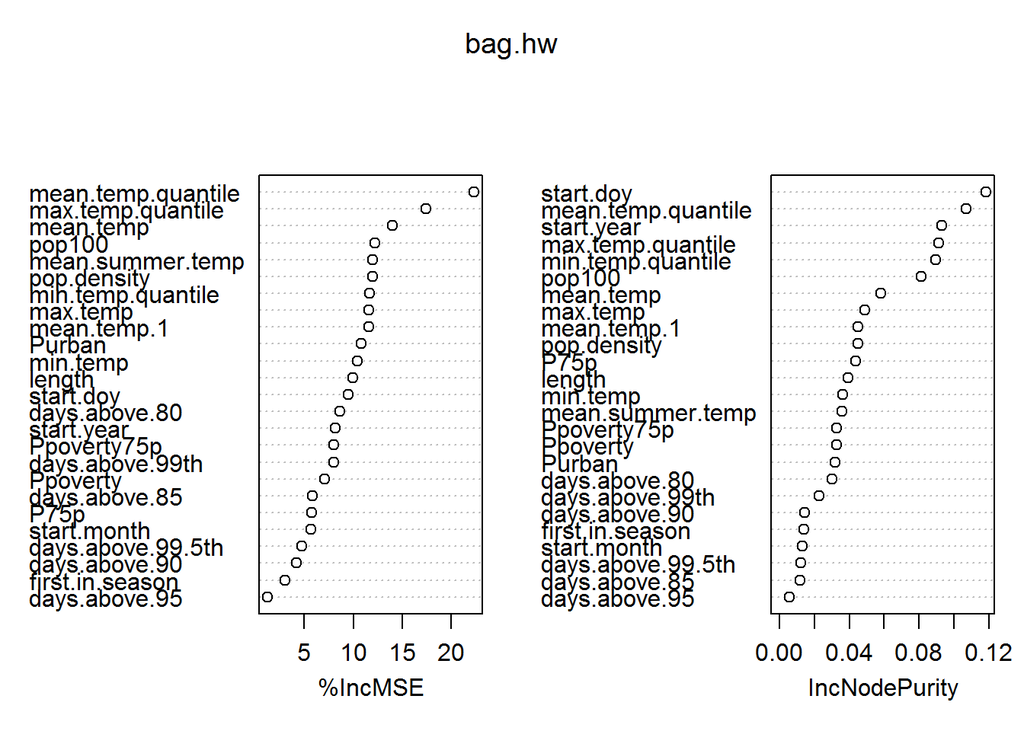

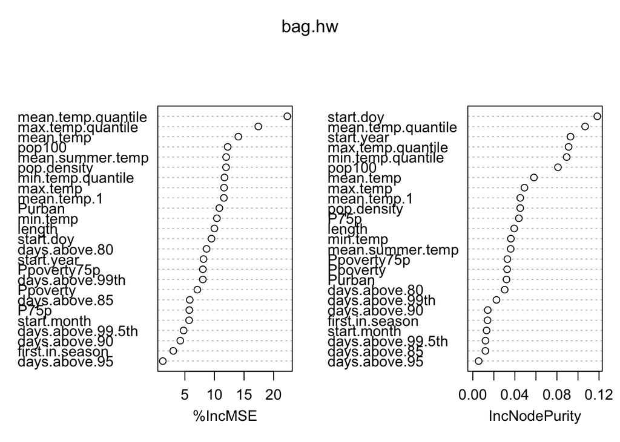

Fitting a random forest model, with tuning:

```r
# Use 10-fold cross validation for tuning to find the best `mtry`
fitControl <- trainControl(method = "cv", number = 10)

set.seed(1)
tuning.rf.hw <- train(post.estimate ~ ., data = to_fit_y2, subset = train,
                   method = "rf", trControl = fitControl, ntree = 10,
                   importance = TRUE, metric="RMSE",
                   maximize = FALSE, tuneLength=5)
```

Here are the results from that tuning process:

```r
tuning.rf.hw
```

```
## Random Forest
##
## 2980 samples
##   25 predictor
##
## No pre-processing
## Resampling: Cross-Validated (10 fold)
## Summary of sample sizes: 1342, 1341, 1339, 1339, 1342, 1342, ...
## Resampling results across tuning parameters:
##
##   mtry  RMSE        Rsquared
##    2    0.02868690  0.04353313
##    7    0.02939747  0.03193592
##   13    0.02879352  0.05844140
##   19    0.02909298  0.04281612
##   25    0.02936563  0.04572643
##
## RMSE was used to select the optimal model using  the smallest value.
## The final value used for the model was mtry = 2.
```

```r
plot(tuning.rf.hw)
```

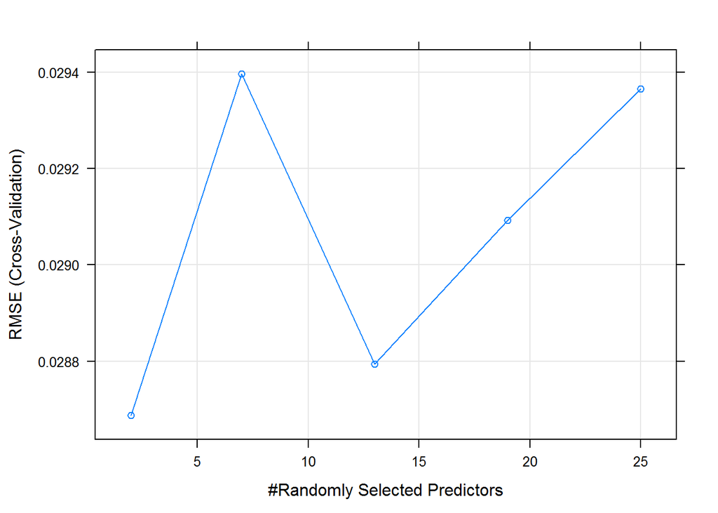

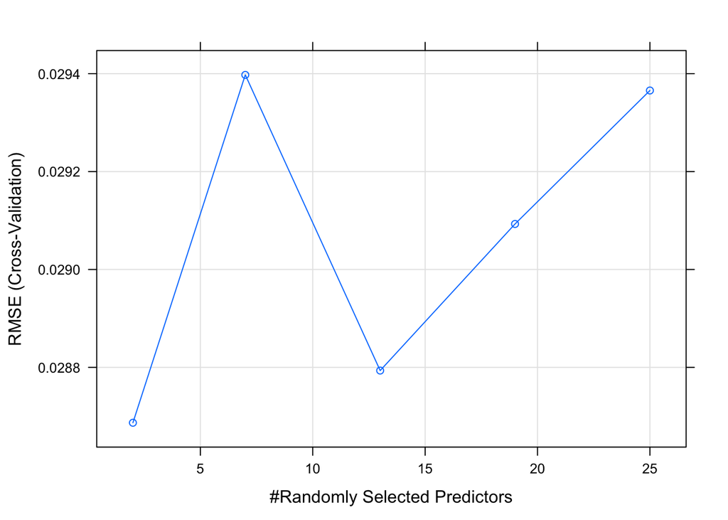

Based on this tuning, the best value for `mtry` in the random forest model for this outcome is 2.

```r
yhat.rf <- predict(tuning.rf.hw$finalModel, newdata = to_fit_y2[test, ])

to_plot <- data.frame(post.estimated_y2 = yhat.rf,
                      true_y2 = to_fit_y2[test, "post.estimate"])
ggplot(to_plot, aes(x = post.estimated_y2, y = true_y2)) +
  geom_point(alpha = 0.2) +
  xlim(range(to_plot)) + ylim(range(to_plot)) +
  theme_minimal() +
  geom_abline(intercept = 0, slope = 1) +
  xlab("post.estimated Y_1") + ylab("True Y_1")
```

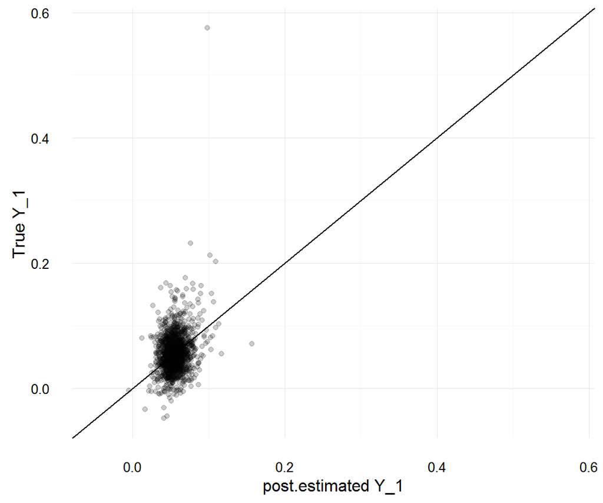

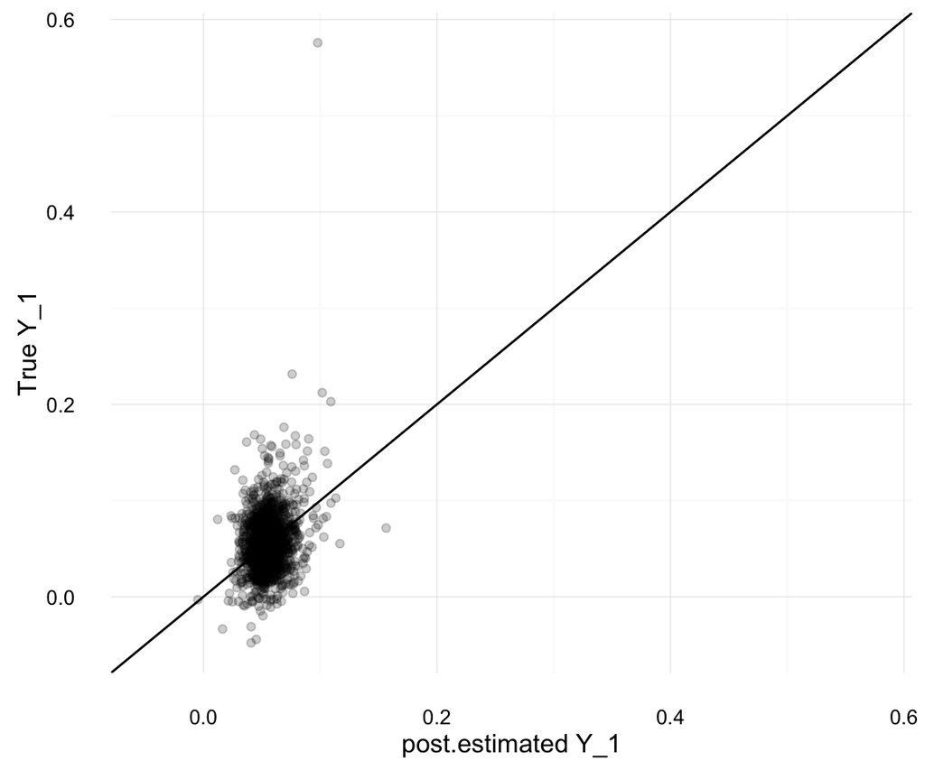

Here are the variable importance plots:

```r
importance(tuning.rf.hw$finalModel)
```

```
##                       %IncMSE IncNodePurity
## mean.temp           1.6553735   0.058466312
## max.temp            1.3640385   0.051028011
## min.temp            1.1714766   0.046887183
## length              0.9847845   0.042060543
## start.doy           1.0131798   0.065750488
## start.month        -0.3155787   0.026427804
## days.above.80       0.9765296   0.033109841
## days.above.85       0.1816741   0.022378240
## days.above.90      -1.5436770   0.013393456
## days.above.95      -0.3068999   0.003580061
## days.above.99th     2.1635011   0.024499024
## days.above.99.5th   2.0880887   0.020387868
## first.in.season    -1.6355017   0.015672980
## mean.temp.quantile  2.9910951   0.062703417
## max.temp.quantile   1.8070116   0.064017116
## min.temp.quantile   1.1866908   0.061353052
## pop100              0.4352054   0.032589698
## Ppoverty            2.1384139   0.039694939
## Ppoverty75p         1.2902534   0.032308060
## Purban              1.2547863   0.033096323
## P75p                0.4270636   0.038712597
## pop.density         1.1476530   0.039703691
## mean.temp.1         2.0539708   0.039198890
## mean.summer.temp    2.8715779   0.038354946
## start.year          0.7517165   0.052745890
```

```r
varImpPlot(tuning.rf.hw$finalModel)
```

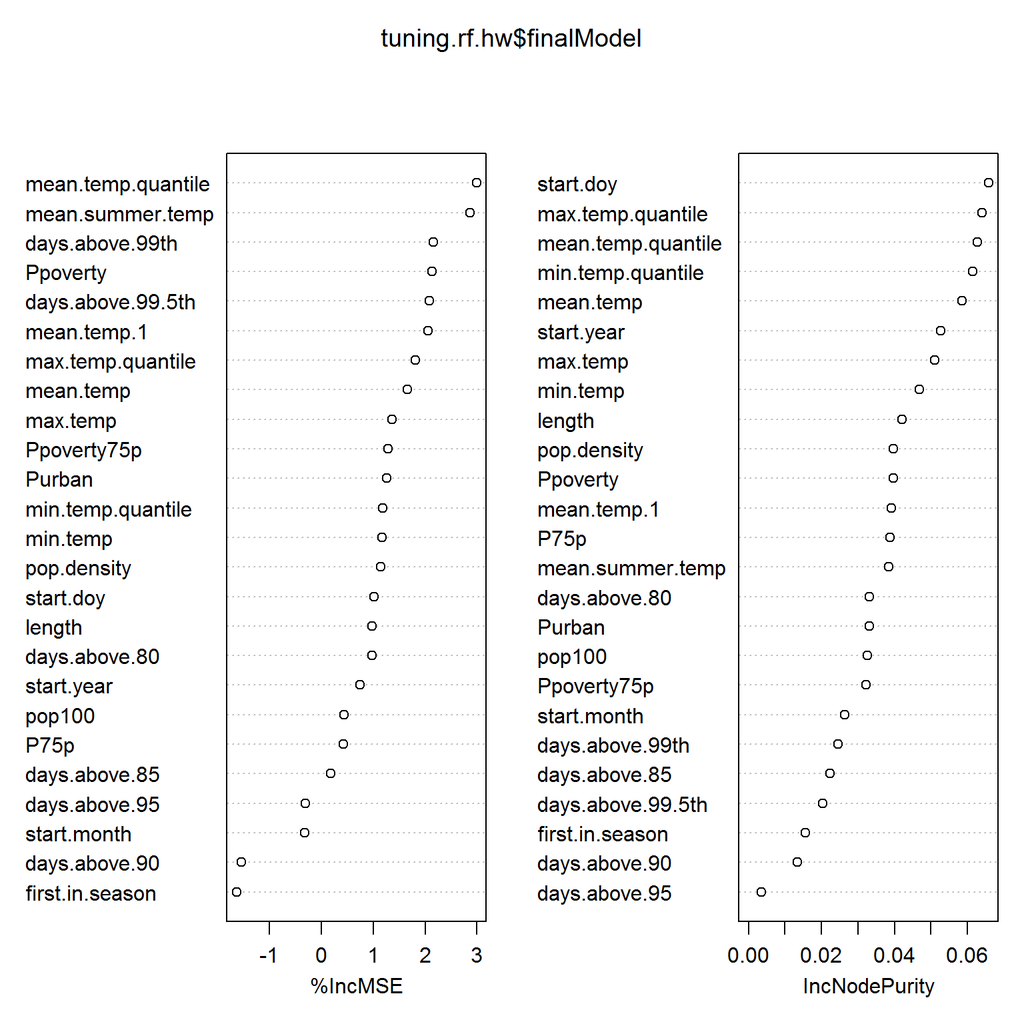

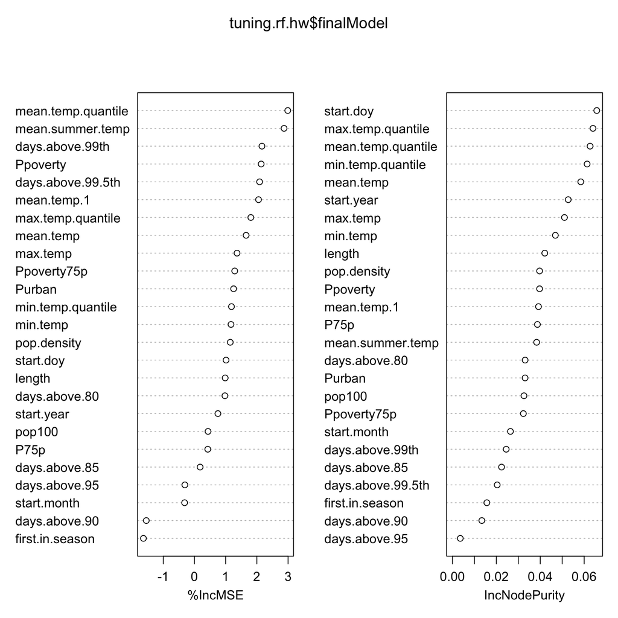

Fit a boosting model, with tuning

```r
#### Tuning to find best mtry for Boosting
gbmgrid <- expand.grid(.interaction.depth = seq(1, 7, by = 2),
                    .n.trees = seq(200, 300, by = 50),
                    .shrinkage = 0.01,
                    .n.minobsinnode = 10)
set.seed(1)


tuning.boost.hw <- train(post.estimate~., data=to_fit_y2, subset = train,
                      method = "gbm",
                      tuneGrid = gbmgrid,
                      trControl = fitControl,
                      verbose = FALSE)
```

Here are the results from that tuning process:

```r
tuning.boost.hw
```

```
## Stochastic Gradient Boosting
##
## 2980 samples
##   25 predictor
##
## No pre-processing
## Resampling: Cross-Validated (10 fold)
## Summary of sample sizes: 1342, 1341, 1339, 1339, 1342, 1342, ...
## Resampling results across tuning parameters:
##
##   interaction.depth  n.trees  RMSE        Rsquared
##   1                  200      0.02822801  0.04119914
##   1                  250      0.02819826  0.04160900
##   1                  300      0.02816541  0.04311130
##   3                  200      0.02789913  0.06539971
##   3                  250      0.02781647  0.06915521
##   3                  300      0.02776648  0.07113787
##   5                  200      0.02770877  0.07665055
##   5                  250      0.02766152  0.07891834
##   5                  300      0.02759800  0.08258896
##   7                  200      0.02770339  0.07581222
##   7                  250      0.02760979  0.08045655
##   7                  300      0.02757758  0.08159351
##
## Tuning parameter 'shrinkage' was held constant at a value of 0.01
##
## Tuning parameter 'n.minobsinnode' was held constant at a value of 10
## RMSE was used to select the optimal model using  the smallest value.
## The final values used for the model were n.trees = 300,
##  interaction.depth = 7, shrinkage = 0.01 and n.minobsinnode = 10.
```

```r
plot(tuning.boost.hw)
```

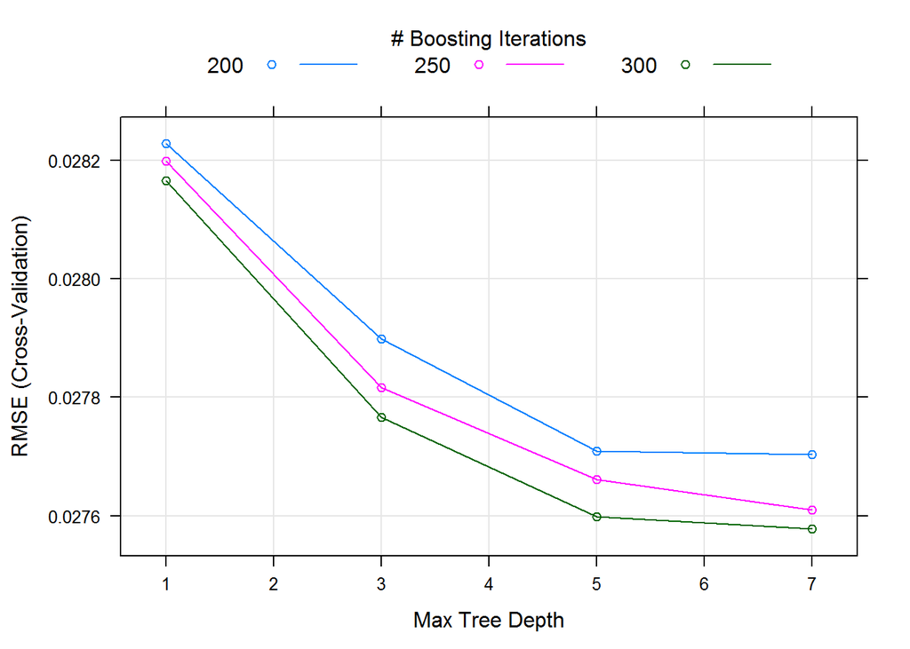

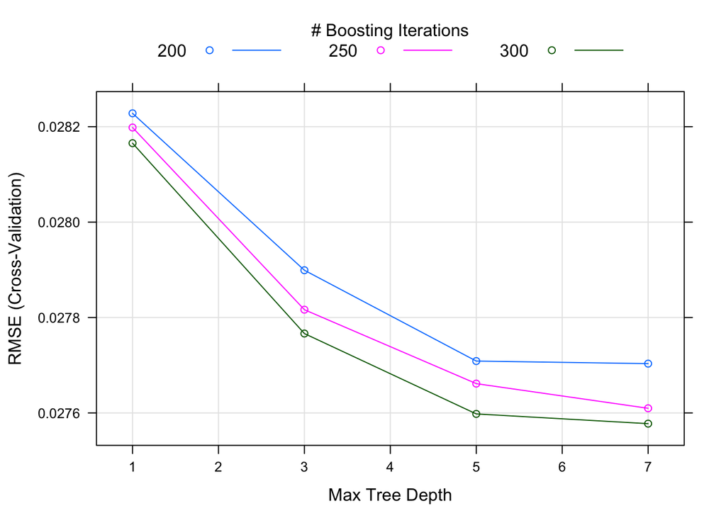

```r
boost.hw <- gbm(post.estimate~., data = to_fit_y2[train,],
                distribution = "gaussian",
                n.trees = tuning.boost.hw$bestTune[,1],
                interaction.depth = tuning.boost.hw$bestTune[,2])
summary(boost.hw)
```

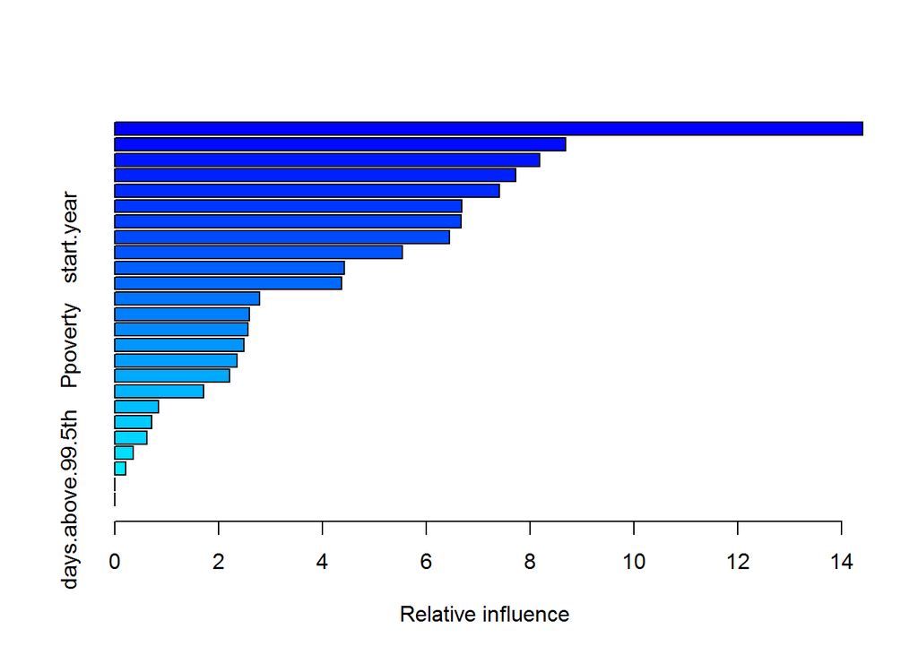

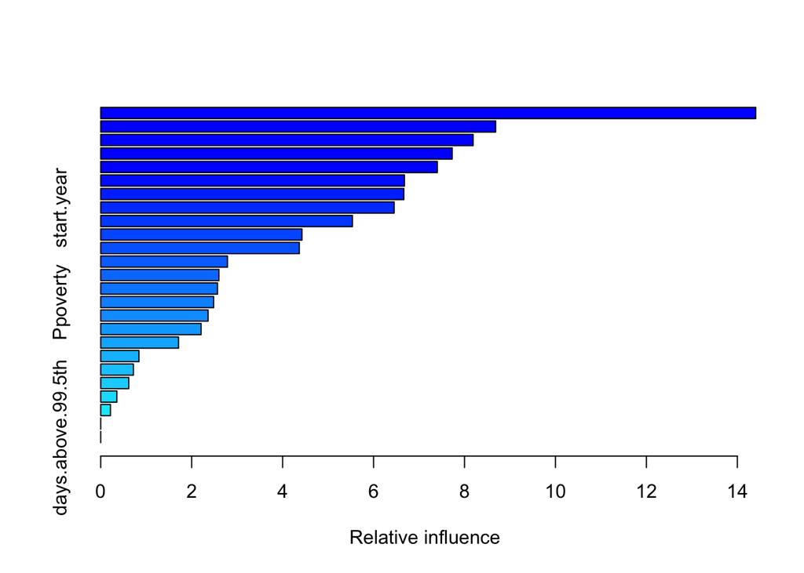

```
##                                   var    rel.inf
## mean.temp.quantile mean.temp.quantile 14.4050442
## pop.density               pop.density  8.6850164
## start.doy                   start.doy  8.1900152
## mean.temp.1               mean.temp.1  7.7287258
## mean.summer.temp     mean.summer.temp  7.4031307
## pop100                         pop100  6.6798474
## max.temp.quantile   max.temp.quantile  6.6663224
## start.year                 start.year  6.4528300
## min.temp.quantile   min.temp.quantile  5.5357672
## max.temp                     max.temp  4.4253893
## length                         length  4.3673207
## days.above.80           days.above.80  2.7878022
## days.above.85           days.above.85  2.5985886
## P75p                             P75p  2.5679490
## Ppoverty                     Ppoverty  2.4829624
## Purban                         Purban  2.3606291
## mean.temp                   mean.temp  2.2065555
## min.temp                     min.temp  1.7114992
## Ppoverty75p               Ppoverty75p  0.8411647
## days.above.99th       days.above.99th  0.7175593
## days.above.90           days.above.90  0.6169421
## first.in.season       first.in.season  0.3551572
## days.above.95           days.above.95  0.2137813
## start.month               start.month  0.0000000
## days.above.99.5th   days.above.99.5th  0.0000000
```

```r
yhat.boost <- predict(boost.hw, newdata = to_fit_y2[test,], n.trees =tuning.boost.hw$bestTune[,1])
hw.test <- to_fit_y2[-train, "post.estimate"]


to_plot <- data.frame(post.estimated_y2 = yhat.boost,
                      true_y2 = to_fit_y2[test, "post.estimate"])
ggplot(to_plot, aes(x = post.estimated_y2, y = true_y2)) +
  geom_point(alpha = 0.2) +
  xlim(range(to_plot)) + ylim(range(to_plot)) +
  theme_minimal() +
  geom_abline(intercept = 0, slope = 1) +
  xlab("post.estimated Y_1") + ylab("True Y_1")
```

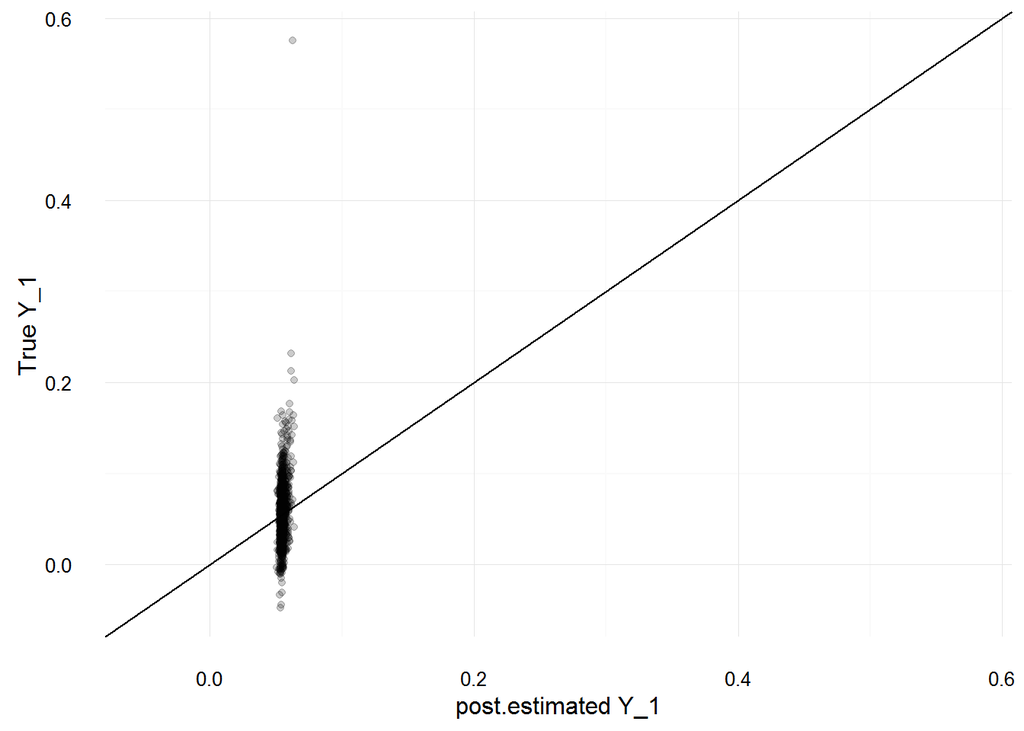

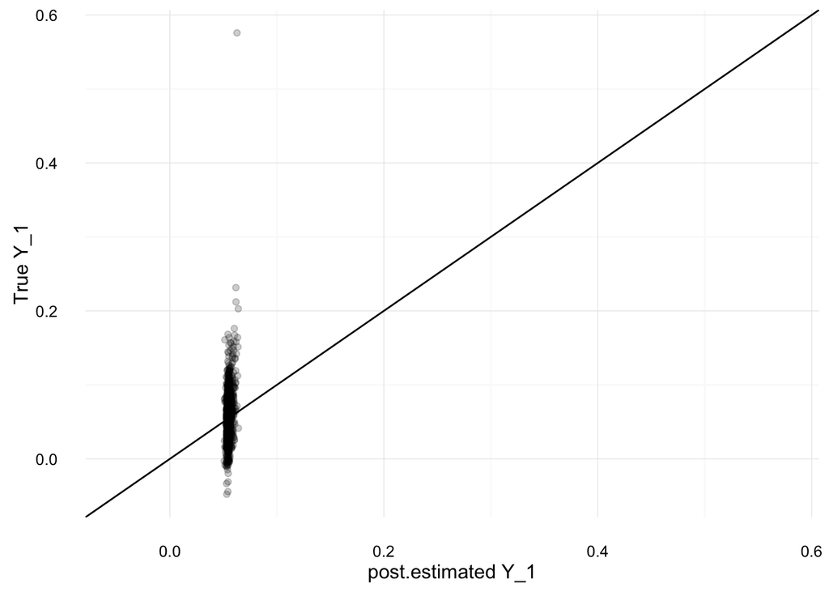

Fit a xgboost model.

```r
df_train <- to_fit_y2[train,]

df_test <- to_fit_y2[-train,]

data <- as.matrix(df_train[,-25])
label=df_train[,25]
```

Tuning

```r
xgb.grid <- expand.grid(nrounds = 10,
                        eta = c(0.01,0.05,0.1),
                        max_depth = c(2,4,6,8,10,14),
                        gamma = 1,
                        colsample_bytree = 0.5,
                        min_child_weight=1
                        )
set.seed(45)
xgb_tune <-train(post.estimate~.,
                 data=df_train,
                 method="xgbTree",
                 trControl=fitControl,
                 tuneGrid=xgb.grid,
                 verbose=T,
                 nthread =3)
xgb_tune
```

```
## eXtreme Gradient Boosting
##
## 1490 samples
##   25 predictor
##
## No pre-processing
## Resampling: Cross-Validated (10 fold)
## Summary of sample sizes: 1341, 1342, 1341, 1342, 1340, 1341, ...
## Resampling results across tuning parameters:
##
##   eta   max_depth  RMSE       Rsquared
##   0.01   2         0.4035206  NaN
##   0.01   4         0.4035206  NaN
##   0.01   6         0.4035206  NaN
##   0.01   8         0.4035206  NaN
##   0.01  10         0.4035206  NaN
##   0.01  14         0.4035206  NaN
##   0.05   2         0.2680906  NaN
##   0.05   4         0.2680906  NaN
##   0.05   6         0.2680906  NaN
##   0.05   8         0.2680906  NaN
##   0.05  10         0.2680906  NaN
##   0.05  14         0.2680906  NaN
##   0.10   2         0.1579149  NaN
##   0.10   4         0.1579149  NaN
##   0.10   6         0.1579149  NaN
##   0.10   8         0.1579149  NaN
##   0.10  10         0.1579149  NaN
##   0.10  14         0.1579149  NaN
##
## Tuning parameter 'nrounds' was held constant at a value of 10
##
## Tuning parameter 'colsample_bytree' was held constant at a value of
##  0.5
## Tuning parameter 'min_child_weight' was held constant at a value of 1
## RMSE was used to select the optimal model using  the smallest value.
## The final values used for the model were nrounds = 10, max_depth = 2,
##  eta = 0.1, gamma = 1, colsample_bytree = 0.5 and min_child_weight = 1.
```